# Collaborative Secure Federated Learning example workflow

In this example, we train collaboratively two mortality classification models (logistic regression and Cox regression) on the dataset $D_2$, split across three nodes. We use a Secure Federated Learning workflow supported by Tune Insight's platform, where models are trained locally using Pytorch library and are aggregated across parties under homomorphic encryption. Local models are never revealed to the other parties, and only the collective global model is shared across them.

### Contact

For more information on the encrypted statistical and machine learning capabilities of the full secure federated platform, do not hesitate to contact as at contact@tuneinsight.com.

### Setup

```python
%load_ext autoreload
%autoreload 2
%matplotlib inline

from IPython.display import Image
from tuneinsight.api.sdk import models
from tuneinsight.api.sdk.models.computation_type import ComputationType
from tuneinsight.client.diapason import Diapason
from dev.scripts.utils import set_dataset_from_df
from typing import List
import pandas as pd
import tuneinsight.utils.time_tools as time
```

[figure not shown]

#### Prepare results

We evaluate the training of a Cox regression and a Logistic regression on the mortality dataset $D_2$, and compare three scenarios to differentiate the impact of distribution and encryption on the obtained result:

- Local: local training of the corresponding model, using all the data (ideal case where data can be centralized, and the whole process can be run with no encryption or additional protection mechanism)
- Federated (Federated Learning): the raw data is not shared across the different parties; only the local models are shared across all parties, and are aggregated in the clear. The contribution form each party is disclosed to the others, and the iterative process is vulnerable to inference and reidentification attacks
- Secure Federated: Neither the raw data nor the local models are shared in the clear. The locally-trained models are encrypted and aggregated under encryption, and differentially-private noise is added to the result before it is released and decrypted to feed the next iteration of training. Local contributions to the global model are not disclosed, and inference and reidentification attacks are mitigated.

```python
final_results = {
    'Local': {
        'cox regression': {},
        'logistic regression': {},
    },
    'Federated': {
        'cox regression': {
            1: {},
            2: {},
            3: {},
        },
        'logistic regression': {
            1: {},
            2: {},
            3: {},
        },
    },
    'Secure Federated': {
        'cox regression': {
            1: {},
            2: {},
            3: {},
        },
        'logistic regression': {
            1: {},
            2: {},
            3: {},
        },
    },
}
```

#### Define the models: Cox regression and Logistic Regression

```python
task_id_cox = 'mortality_cox'
task_def_cox = {
    "n_inputs": 11,
    "n_classes": 2,
    "model": {
        "type": "cox",
        "pretrained": False,
    },
    "shuffle_data": True,
    "balance_train_classes": True,
    "batch_size": 2048,
    "drop_last_batch": True,
    "loss_criteria": "cross_entropy_loss"
}
```

```python
task_id_logreg = 'mortality_logreg'
task_def_logreg = {
    "n_inputs": 11,
    "n_classes": 2,
    "model": {
        "type": "logreg",
        "pretrained": False,
    },
    "shuffle_data": True,
    "balance_train_classes": True,
    "batch_size": 2048,
    "drop_last_batch": True,
    "loss_criteria": "cross_entropy_loss"
}
```

### Local Training

#### Create clients, create project and share project

```python
clients_local : List[Diapason] = []
num_clients_local = 4

for i in range(num_clients_local):
    conf_path = "../test/configs/hybridfl_multi_node.yml"
    client_url = f'http://hybridfl-node{i}.cluster.tuneinsight.net/api'
    client = Diapason.from_config_path(path=conf_path, url=client_url)
    client.client.timeout = 60*60*15
    clients_local.append(client)

root_client = clients_local[0]
client_local = clients_local[1]

project_name = "mortality_risk_local"

project_local = root_client.new_project(name=project_name, clear_if_exists=True)
project_local.set_computation(definition=models.HybridFL(type=ComputationType("hybridFL")))
project_local.share()
```

##### Set train and test dataset for local training: Synthetic $D_2$ dataset

```python
root_datasource = pd.DataFrame(
    columns=['type', 'bucket', 'train_path', 'test_path'],
    data=[[
        's3stream',
        'fl-data',
        f'mortality/empty.csv',
        f'mortality/empty.csv'
    ]])
dataset_sources_local = [root_datasource]

dataset_source_local = pd.DataFrame(
    columns=['type', 'bucket', 'train_path', 'test_path'],
    data=[[
        's3stream',
        'fl-data',
        f'mortality/train_full.csv',
        f'mortality/test_full.csv'
    ]])
dataset_sources_local.append(dataset_source_local)

for i in range(num_clients_local-2):
    dataset_source_local = pd.DataFrame(
        columns=['type', 'bucket', 'train_path', 'test_path'],
        data=[[
            's3stream',
            'fl-data',
            f'mortality/train_{i+1}.csv',
            f'mortality/test_{i+1}.csv'
        ]])
    dataset_sources_local.append(dataset_source_local)

for i, client in enumerate(clients_local):
    set_dataset_from_df(clients=[client], dataset=dataset_sources_local[i], project=project_local, name="dataset_source_local", split=False)

dataset_sources_local[1]
```

|  | type | bucket | train_path | test_path |
| --- | --- | --- | --- | --- |
| 0 | s3stream | fl-data | mortality/train_full.csv | mortality/test_full.csv |

##### Set training parameters

```python
learning_params = models.HybridFLLearningParams(
    fl_rounds = 1,
    local_epochs = 2,
    num_workers = 8,
    batch_size = 2048,
    learning_rate = 0.01,
    momentum = 0.9,
    gradient_clipping = 0, # No clipping
)
```

#### Run the computation with Cox Regression

```python
hybrid_fl = project_local.new_hybrid_fl()
hybrid_fl.max_timeout = 300 * 60 * time.second
_ = hybrid_fl.create_from_params(task_id=task_id_cox, learning_params=learning_params, task_def=task_def_cox)
```

```python
# Wait for the client to get its result
time.sleep(60*time.second)
```

```python
results = hybrid_fl.get_client_result(client_local)[0].get_ml_result()
```

##### Add local results for Cox Regression

```python
train_results_index = 0
test_results_index = 1

final_results['Local']['cox regression'] = hybrid_fl.get_results(results.history, local_only = True)[test_results_index]
```

#### Run the computation with Logistic Regression

```python
hybrid_fl = project_local.new_hybrid_fl()
hybrid_fl.max_timeout = 300 * 60 * time.second
_ = hybrid_fl.create_from_params(task_id=task_id_logreg, learning_params=learning_params, task_def=task_def_logreg)
```

```python
# Wait for the client to get its result
time.sleep(60*time.second)
```

```python
results = hybrid_fl.get_client_result(client_local)[0].get_ml_result()
```

##### Add local results for Logistic Regression

```python
final_results['Local']['logistic regression'] = hybrid_fl.get_results(results.history, local_only = True)[test_results_index]
```

### Collaborative Training

#### Create clients, create project and share project

```python
clients : List[Diapason] = []
num_clients = 4

for i in range(num_clients):
    conf_path = "../test/configs/hybridfl_multi_node.yml"
    client_url = f'http://hybridfl-node{i}.cluster.tuneinsight.net/api'
    client = Diapason.from_config_path(path=conf_path, url=client_url)
    client.client.timeout = 60*60*15
    clients.append(client)

root_client = clients[0]

project_name = "mortality_risk_federated"

project = root_client.new_project(name=project_name, clear_if_exists=True)
project.set_computation(definition=models.HybridFL(type=ComputationType("hybridFL")))
project.share()

print(project)
```

```
id: fbef963c-d909-46fd-8f11-b8b96805901f
name: mortality_risk_federated
participants:
	node: organization_0 (organization: Tune Insight)
	input tables :

	node: organization_1 (organization: Hospital 1)
	input tables :

	node: organization_2 (organization: Hospital 2)
	input tables :

	node: organization_3 (organization: Hospital 3)
	input tables :
```

##### Set train and test dataset for each participant: Synthetic $D_2$ dataset split randomly across 3 participants

```python
root_datasource = pd.DataFrame(
    columns=['type', 'bucket', 'train_path', 'test_path'],
    data=[[
        's3stream',
        'fl-data',
        f'mortality/empty.csv',
        f'mortality/empty.csv'
    ]])

image_dataset_sources = [root_datasource]

for i in range(num_clients-1):
    image_dataset_source = pd.DataFrame(
        columns=['type', 'bucket', 'train_path', 'test_path'],
        data=[[
            's3stream',
            'fl-data',
            f'mortality/train_{i}.csv',
            f'mortality/test_{i}.csv'
        ]])
    image_dataset_sources.append(image_dataset_source)

for i, client in enumerate(clients):
    set_dataset_from_df(clients=[client], dataset=image_dataset_sources[i], project=project, name="image_dataset_source", split=False)

display_df = pd.concat(image_dataset_sources)
display_df.index = [participant.node.organization.name for participant in project.model.participants]
display_df
```

|  | type | bucket | train_path | test_path |
| --- | --- | --- | --- | --- |
| Tune Insight | s3stream | fl-data | mortality/empty.csv | mortality/empty.csv |
| Hospital 1 | s3stream | fl-data | mortality/train_0.csv | mortality/test_0.csv |
| Hospital 2 | s3stream | fl-data | mortality/train_1.csv | mortality/test_1.csv |
| Hospital 3 | s3stream | fl-data | mortality/train_2.csv | mortality/test_2.csv |

#### Set federated training without security parameters

```python
learning_params_federated = models.HybridFLLearningParams(
    fl_rounds = 2,
    local_epochs = 1,
    num_workers = 8,
    batch_size = 256,
    learning_rate = 0.01,
    momentum = 0.9,
    gradient_clipping = 0, # No gradient clipping
    add_noise = False,
)
```

#### Run the computation with Cox Regression

```python
hybrid_fl = project.new_hybrid_fl()
hybrid_fl.max_timeout = 300 * 60 * time.second
_ = hybrid_fl.create_from_params(task_id=task_id_cox, learning_params=learning_params_federated, task_def=task_def_cox)
```

```python
# Wait for all nodes to get their result
time.sleep(60*time.second)
```

```python
results = [hybrid_fl.get_client_result(client)[0].get_ml_result() for client in clients]
```

##### Add Collective results for Cox Regression

```python
train_results_index = 0
test_results_index = 1
for i, _ in enumerate(clients):
    if i == 0: continue # skip root
    final_results['Federated']['cox regression'][i] = hybrid_fl.get_results(results[i].history)[test_results_index]
```

#### Run the computation with Logistic Regression

```python
hybrid_fl = project.new_hybrid_fl()
hybrid_fl.max_timeout = 300 * 60 * time.second
_ = hybrid_fl.create_from_params(task_id=task_id_logreg, learning_params=learning_params, task_def=task_def_logreg)
```

```python
# Wait for all nodes to get their result
time.sleep(60*time.second)
```

```python
results = [hybrid_fl.get_client_result(client)[0].get_ml_result() for client in clients]
```

##### Add Collective results for Logistic Regression

```python
train_results_index = 0
test_results_index = 1
for i, _ in enumerate(clients):
    if i == 0: continue # skip root
    final_results['Federated']['logistic regression'][i] = hybrid_fl.get_results(results[i].history)[test_results_index]
```

#### Set secure federated training parameters

```python
learning_params_federated_secure = models.HybridFLLearningParams(
    fl_rounds = 2,
    local_epochs = 1,
    num_workers = 8,
    batch_size = 2048,
    learning_rate = 0.01,
    momentum = 0.9,
    gradient_clipping = 0.1,
    epsilon = 1,
    delta = 0.001,
)
```

#### Run the computation with Cox Regression

```python
hybrid_fl = project.new_hybrid_fl()
hybrid_fl.max_timeout = 300 * 60 * time.second
_ = hybrid_fl.create_from_params(task_id=task_id_cox, learning_params=learning_params_federated_secure, task_def=task_def_cox)
```

```python
# Wait for all nodes to get their result
time.sleep(60*time.second)
```

```python
results = [hybrid_fl.get_client_result(client)[0].get_ml_result() for client in clients]
```

### Training curve of one client's Cox regression

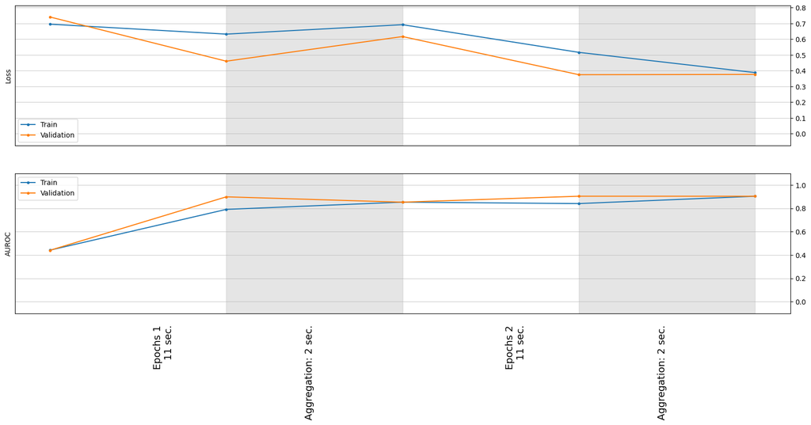

```python
hybrid_fl.display_results(results[1].history, metrics_to_display = ['loss', 'auroc'])
```

##### Add Secure Collective results for Cox Regression

```python
train_results_index = 0
test_results_index = 1
for i, _ in enumerate(clients):
    if i == 0: continue # skip root
    final_results['Secure Federated']['cox regression'][i] = hybrid_fl.get_results(results[i].history)[test_results_index]
```

#### Run the computation with Logistic Regression

```python
hybrid_fl = project.new_hybrid_fl()
hybrid_fl.max_timeout = 300 * 60 * time.second
_ = hybrid_fl.create_from_params(task_id=task_id_logreg, learning_params=learning_params_federated_secure, task_def=task_def_logreg)
```

```python
# Wait for all nodes to get their result
time.sleep(60*time.second)
```

```python
results = [hybrid_fl.get_client_result(client)[0].get_ml_result() for client in clients]
```

### Training curve of one client's logistic regression

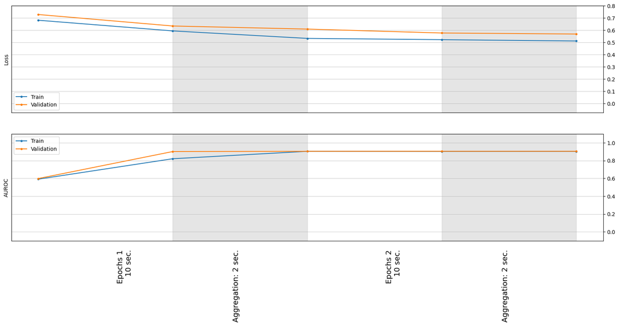

```python
hybrid_fl.display_results(results[1].history, metrics_to_display = ['loss', 'auroc'])
```

##### Add Secure Collective results for Logistic Regression

```python
train_results_index = 0
test_results_index = 1
for i, _ in enumerate(clients):
    if i == 0: continue # skip root
    final_results['Secure Federated']['logistic regression'][i] = hybrid_fl.get_results(results[i].history)[test_results_index]
```

### Display Results

```python
display_tables = {}
reference_node = 1
for metric in ['auroc', 'loss']:
    display_tables[metric] = {}
    for mode, mode_item in final_results.items():
        display_tables[metric][mode] = {}
        for reg_type, reg_type_item in mode_item.items():
            if mode == 'Local':
                display_tables[metric][mode][reg_type] = reg_type_item[metric]
            else:
                display_tables[metric][mode][reg_type] = reg_type_item[reference_node][metric]
```

```python
df = pd.DataFrame.from_dict(display_tables['auroc'], orient="index")
df.style.set_caption("AUROC for Node 1")
```

AUROC

[output not shown]

```python
df = pd.DataFrame.from_dict(display_tables['loss'], orient="index")
df.style.set_caption("Cross Entropy Loss for Node 1")
```

Cross Entropy Loss

[output not shown]